# Risk Factor Analysis

## Outcome Variable

**Outcome Variable:** wasted

## Predictor Variables

**Intervention Variable:** parity

**Adjustment Set:**

- arm
- W_mage
- meducyrs
- feducyrs
- hhwealth_quart
- W_mhtcm
- vagbrth
- W_nrooms
- impsan
- delta_W_mage
- delta_meducyrs
- delta_feducyrs
- delta_hhwealth_quart
- delta_W_mhtcm
- delta_vagbrth
- delta_W_nrooms
- delta_impsan

## Stratifying Variables

The analysis was stratified on these variable(s):

- agecat
- studyid
- country

## Data Summary

| agecat | studyid | country | parity | wasted | n_cell | n |
| --- | --- | --- | --- | --- | --- | --- |
| Birth | ki1000304b-SAS-CompFeed | INDIA | 1 | 0 | 37 | 166 |
| Birth | ki1000304b-SAS-CompFeed | INDIA | 1 | 1 | 4 | 166 |
| Birth | ki1000304b-SAS-CompFeed | INDIA | 2 | 0 | 41 | 166 |
| Birth | ki1000304b-SAS-CompFeed | INDIA | 2 | 1 | 3 | 166 |
| Birth | ki1000304b-SAS-CompFeed | INDIA | 3+ | 0 | 77 | 166 |
| Birth | ki1000304b-SAS-CompFeed | INDIA | 3+ | 1 | 4 | 166 |
| Birth | ki1101329-Keneba | GAMBIA | 1 | 0 | 139 | 1292 |
| Birth | ki1101329-Keneba | GAMBIA | 1 | 1 | 3 | 1292 |
| Birth | ki1101329-Keneba | GAMBIA | 2 | 0 | 131 | 1292 |
| Birth | ki1101329-Keneba | GAMBIA | 2 | 1 | 2 | 1292 |
| Birth | ki1101329-Keneba | GAMBIA | 3+ | 0 | 996 | 1292 |
| Birth | ki1101329-Keneba | GAMBIA | 3+ | 1 | 21 | 1292 |
| Birth | ki1126311-ZVITAMBO | ZIMBABWE | 1 | 0 | 4497 | 12915 |
| Birth | ki1126311-ZVITAMBO | ZIMBABWE | 1 | 1 | 1064 | 12915 |
| Birth | ki1126311-ZVITAMBO | ZIMBABWE | 2 | 0 | 3358 | 12915 |
| Birth | ki1126311-ZVITAMBO | ZIMBABWE | 2 | 1 | 524 | 12915 |
| Birth | ki1126311-ZVITAMBO | ZIMBABWE | 3+ | 0 | 3000 | 12915 |
| Birth | ki1126311-ZVITAMBO | ZIMBABWE | 3+ | 1 | 472 | 12915 |
| Birth | ki1135781-COHORTS | GUATEMALA | 1 | 0 | 66 | 756 |
| Birth | ki1135781-COHORTS | GUATEMALA | 1 | 1 | 28 | 756 |
| Birth | ki1135781-COHORTS | GUATEMALA | 2 | 0 | 87 | 756 |
| Birth | ki1135781-COHORTS | GUATEMALA | 2 | 1 | 31 | 756 |
| Birth | ki1135781-COHORTS | GUATEMALA | 3+ | 0 | 411 | 756 |
| Birth | ki1135781-COHORTS | GUATEMALA | 3+ | 1 | 133 | 756 |
| Birth | ki1135781-COHORTS | INDIA | 1 | 0 | 505 | 3855 |
| Birth | ki1135781-COHORTS | INDIA | 1 | 1 | 136 | 3855 |
| Birth | ki1135781-COHORTS | INDIA | 2 | 0 | 823 | 3855 |
| Birth | ki1135781-COHORTS | INDIA | 2 | 1 | 159 | 3855 |
| Birth | ki1135781-COHORTS | INDIA | 3+ | 0 | 1876 | 3855 |
| Birth | ki1135781-COHORTS | INDIA | 3+ | 1 | 356 | 3855 |

[output cut: 132 more lines]

The following strata were considered:

- agecat: 24 months, studyid: ki1017093b-PROVIDE, country: BANGLADESH
- agecat: 24 months, studyid: ki1066203-TanzaniaChild2, country: TANZANIA, UNITED REPUBLIC OF
- agecat: 24 months, studyid: ki1101329-Keneba, country: GAMBIA
- agecat: 24 months, studyid: ki1113344-GMS-Nepal, country: NEPAL
- agecat: 24 months, studyid: ki1126311-ZVITAMBO, country: ZIMBABWE
- agecat: 24 months, studyid: ki1135781-COHORTS, country: GUATEMALA
- agecat: 24 months, studyid: ki1135781-COHORTS, country: INDIA
- agecat: 24 months, studyid: ki1135781-COHORTS, country: PHILIPPINES
- agecat: 24 months, studyid: kiGH5241-JiVitA-3, country: BANGLADESH
- agecat: 6 months, studyid: ki1000304b-SAS-CompFeed, country: INDIA
- agecat: 6 months, studyid: ki1000304b-SAS-FoodSuppl, country: INDIA
- agecat: 6 months, studyid: ki1017093b-PROVIDE, country: BANGLADESH
- agecat: 6 months, studyid: ki1066203-TanzaniaChild2, country: TANZANIA, UNITED REPUBLIC OF
- agecat: 6 months, studyid: ki1101329-Keneba, country: GAMBIA
- agecat: 6 months, studyid: ki1113344-GMS-Nepal, country: NEPAL
- agecat: 6 months, studyid: ki1126311-ZVITAMBO, country: ZIMBABWE
- agecat: 6 months, studyid: ki1135781-COHORTS, country: GUATEMALA
- agecat: 6 months, studyid: ki1135781-COHORTS, country: INDIA
- agecat: 6 months, studyid: ki1135781-COHORTS, country: PHILIPPINES
- agecat: 6 months, studyid: kiGH5241-JiVitA-3, country: BANGLADESH
- agecat: Birth, studyid: ki1000304b-SAS-CompFeed, country: INDIA
- agecat: Birth, studyid: ki1101329-Keneba, country: GAMBIA
- agecat: Birth, studyid: ki1126311-ZVITAMBO, country: ZIMBABWE
- agecat: Birth, studyid: ki1135781-COHORTS, country: GUATEMALA
- agecat: Birth, studyid: ki1135781-COHORTS, country: INDIA
- agecat: Birth, studyid: ki1135781-COHORTS, country: PHILIPPINES
- agecat: Birth, studyid: kiGH5241-JiVitA-3, country: BANGLADESH

### Dropped Strata

Some strata were dropped due to rare outcomes:

- agecat: Birth, studyid: ki1000304b-SAS-CompFeed, country: INDIA
- agecat: Birth, studyid: ki1101329-Keneba, country: GAMBIA
- agecat: 6 months, studyid: ki1135781-COHORTS, country: GUATEMALA
- agecat: 24 months, studyid: ki1066203-TanzaniaChild2, country: TANZANIA, UNITED REPUBLIC OF

## Methods Detail

We’re interested in the causal parameters $E[Y_a]$ for all values of $a \in \mathcal{A}$. These parameters represent the mean outcome if, possibly contrary to fact, we intervened to set all units to have $A=a$. Under the randomization and positivity assumptions, these are identified by the statistical parameters $\psi_a=E_W[E_{Y|A,W}(Y|A=a,W)]$. In addition, we’re interested in the mean of $Y$, $E[Y]$ under no intervention (the observed mean). We will estimate these parameters by using SuperLearner to fit the relevant likelihood factors – $E_{Y|A,W}(Y|A=a,W)$ and $p(A=a|W)$, and then updating our likelihood fit using a joint TMLE.

For unadjusted analyses ($W=\{\}$), initial likelihoods were estimated using Lrnr_glm to estimate the simple $E(Y|A)$ and Lrnr_mean to estimate $p(A)$. For adjusted analyses, a small library containing Lrnr_glmnet, Lrnr_xgboost, and Lrnr_mean was used.

Having estimated these parameters, we will then use the delta method to estimate relative risks and attributable risks relative to a prespecified baseline level of $A$.

# Results Detail

## Results Plots

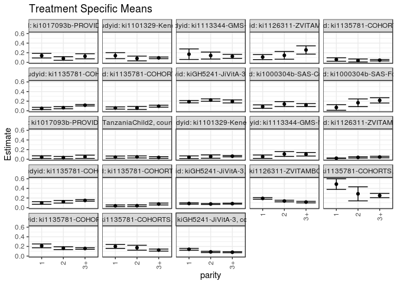

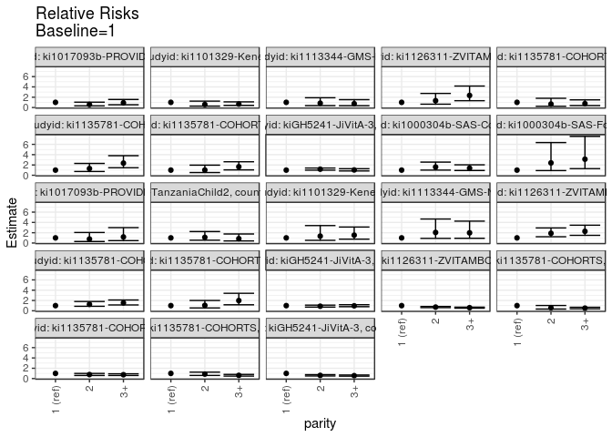

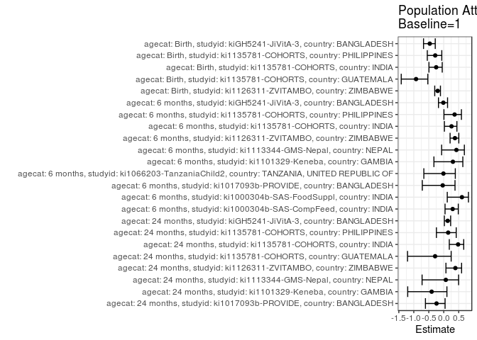

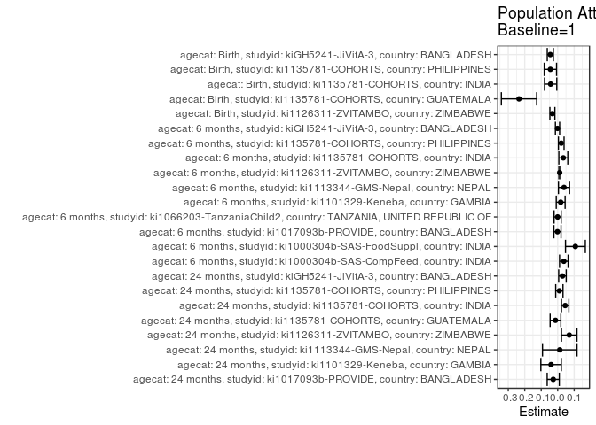

## Results Table

### Parameter: TSM

| agecat | studyid | country | intervention_level | baseline_level | estimate | ci_lower | ci_upper |
| --- | --- | --- | --- | --- | --- | --- | --- |
| Birth | ki1126311-ZVITAMBO | ZIMBABWE | 1 | NA | 0.1916592 | 0.1748799 | 0.2084384 |
| Birth | ki1126311-ZVITAMBO | ZIMBABWE | 2 | NA | 0.1370732 | 0.1204176 | 0.1537287 |
| Birth | ki1126311-ZVITAMBO | ZIMBABWE | 3+ | NA | 0.1154152 | 0.0999469 | 0.1308834 |
| Birth | ki1135781-COHORTS | GUATEMALA | 1 | NA | 0.4887777 | 0.3782822 | 0.5992732 |
| Birth | ki1135781-COHORTS | GUATEMALA | 2 | NA | 0.2869596 | 0.1405505 | 0.4333686 |
| Birth | ki1135781-COHORTS | GUATEMALA | 3+ | NA | 0.2516018 | 0.2067391 | 0.2964645 |
| Birth | ki1135781-COHORTS | INDIA | 1 | NA | 0.2115318 | 0.1720215 | 0.2510421 |
| Birth | ki1135781-COHORTS | INDIA | 2 | NA | 0.1635220 | 0.1349202 | 0.1921237 |
| Birth | ki1135781-COHORTS | INDIA | 3+ | NA | 0.1570546 | 0.1401084 | 0.1740009 |
| Birth | ki1135781-COHORTS | PHILIPPINES | 1 | NA | 0.1998486 | 0.1594501 | 0.2402471 |
| Birth | ki1135781-COHORTS | PHILIPPINES | 2 | NA | 0.1735502 | 0.1224674 | 0.2246330 |
| Birth | ki1135781-COHORTS | PHILIPPINES | 3+ | NA | 0.1236766 | 0.1023259 | 0.1450273 |
| Birth | kiGH5241-JiVitA-3 | BANGLADESH | 1 | NA | 0.1407371 | 0.1215749 | 0.1598993 |
| Birth | kiGH5241-JiVitA-3 | BANGLADESH | 2 | NA | 0.0865168 | 0.0734208 | 0.0996127 |
| Birth | kiGH5241-JiVitA-3 | BANGLADESH | 3+ | NA | 0.0793384 | 0.0688125 | 0.0898643 |
| 6 months | ki1000304b-SAS-CompFeed | INDIA | 1 | NA | 0.0872611 | 0.0509447 | 0.1235775 |
| 6 months | ki1000304b-SAS-CompFeed | INDIA | 2 | NA | 0.1396185 | 0.0883647 | 0.1908723 |
| 6 months | ki1000304b-SAS-CompFeed | INDIA | 3+ | NA | 0.1196359 | 0.0885710 | 0.1507008 |
| 6 months | ki1000304b-SAS-FoodSuppl | INDIA | 1 | NA | 0.0694444 | 0.0106475 | 0.1282414 |
| 6 months | ki1000304b-SAS-FoodSuppl | INDIA | 2 | NA | 0.1666667 | 0.0868626 | 0.2464708 |
| 6 months | ki1000304b-SAS-FoodSuppl | INDIA | 3+ | NA | 0.2165899 | 0.1617098 | 0.2714700 |
| 6 months | ki1017093b-PROVIDE | BANGLADESH | 1 | NA | 0.0426540 | 0.0153646 | 0.0699435 |
| 6 months | ki1017093b-PROVIDE | BANGLADESH | 2 | NA | 0.0330189 | 0.0089451 | 0.0570926 |
| 6 months | ki1017093b-PROVIDE | BANGLADESH | 3+ | NA | 0.0503145 | 0.0163082 | 0.0843208 |
| 6 months | ki1066203-TanzaniaChild2 | TANZANIA, UNITED REPUBLIC OF | 1 | NA | 0.0430879 | 0.0197784 | 0.0663974 |
| 6 months | ki1066203-TanzaniaChild2 | TANZANIA, UNITED REPUBLIC OF | 2 | NA | 0.0475367 | 0.0261302 | 0.0689432 |
| 6 months | ki1066203-TanzaniaChild2 | TANZANIA, UNITED REPUBLIC OF | 3+ | NA | 0.0364559 | 0.0185879 | 0.0543239 |
| 6 months | ki1101329-Keneba | GAMBIA | 1 | NA | 0.0410256 | 0.0131775 | 0.0688738 |
| 6 months | ki1101329-Keneba | GAMBIA | 2 | NA | 0.0548780 | 0.0200120 | 0.0897441 |
| 6 months | ki1101329-Keneba | GAMBIA | 3+ | NA | 0.0625000 | 0.0491515 | 0.0758485 |
| 6 months | ki1113344-GMS-Nepal | NEPAL | 1 | NA | 0.0522876 | 0.0169834 | 0.0875917 |
| 6 months | ki1113344-GMS-Nepal | NEPAL | 2 | NA | 0.1073826 | 0.0576271 | 0.1571380 |
| 6 months | ki1113344-GMS-Nepal | NEPAL | 3+ | NA | 0.1034483 | 0.0664686 | 0.1404280 |
| 6 months | ki1126311-ZVITAMBO | ZIMBABWE | 1 | NA | 0.0200627 | 0.0148499 | 0.0252756 |
| 6 months | ki1126311-ZVITAMBO | ZIMBABWE | 2 | NA | 0.0378903 | 0.0244449 | 0.0513356 |
| 6 months | ki1126311-ZVITAMBO | ZIMBABWE | 3+ | NA | 0.0456014 | 0.0305750 | 0.0606277 |
| 6 months | ki1135781-COHORTS | INDIA | 1 | NA | 0.0970905 | 0.0690626 | 0.1251184 |
| 6 months | ki1135781-COHORTS | INDIA | 2 | NA | 0.1214417 | 0.0944098 | 0.1484736 |
| 6 months | ki1135781-COHORTS | INDIA | 3+ | NA | 0.1494612 | 0.1334594 | 0.1654630 |
| 6 months | ki1135781-COHORTS | PHILIPPINES | 1 | NA | 0.0379233 | 0.0201427 | 0.0557038 |
| 6 months | ki1135781-COHORTS | PHILIPPINES | 2 | NA | 0.0398881 | 0.0223318 | 0.0574444 |
| 6 months | ki1135781-COHORTS | PHILIPPINES | 3+ | NA | 0.0752523 | 0.0557082 | 0.0947963 |
| 6 months | kiGH5241-JiVitA-3 | BANGLADESH | 1 | NA | 0.0856877 | 0.0721180 | 0.0992575 |
| 6 months | kiGH5241-JiVitA-3 | BANGLADESH | 2 | NA | 0.0760654 | 0.0657426 | 0.0863881 |
| 6 months | kiGH5241-JiVitA-3 | BANGLADESH | 3+ | NA | 0.0828557 | 0.0726034 | 0.0931080 |
| 24 months | ki1017093b-PROVIDE | BANGLADESH | 1 | NA | 0.1395051 | 0.0919711 | 0.1870390 |
| 24 months | ki1017093b-PROVIDE | BANGLADESH | 2 | NA | 0.0809541 | 0.0435143 | 0.1183940 |
| 24 months | ki1017093b-PROVIDE | BANGLADESH | 3+ | NA | 0.1268888 | 0.0739998 | 0.1797777 |
| 24 months | ki1101329-Keneba | GAMBIA | 1 | NA | 0.1397351 | 0.0771070 | 0.2023631 |
| 24 months | ki1101329-Keneba | GAMBIA | 2 | NA | 0.0811192 | 0.0319554 | 0.1302831 |
| 24 months | ki1101329-Keneba | GAMBIA | 3+ | NA | 0.0939085 | 0.0762407 | 0.1115764 |
| 24 months | ki1113344-GMS-Nepal | NEPAL | 1 | NA | 0.1701272 | 0.0608394 | 0.2794150 |
| 24 months | ki1113344-GMS-Nepal | NEPAL | 2 | NA | 0.1418761 | 0.0693138 | 0.2144384 |
| 24 months | ki1113344-GMS-Nepal | NEPAL | 3+ | NA | 0.1251869 | 0.0837863 | 0.1665875 |
| 24 months | ki1126311-ZVITAMBO | ZIMBABWE | 1 | NA | 0.1101097 | 0.0579524 | 0.1622670 |
| 24 months | ki1126311-ZVITAMBO | ZIMBABWE | 2 | NA | 0.1458857 | 0.0658316 | 0.2259399 |
| 24 months | ki1126311-ZVITAMBO | ZIMBABWE | 3+ | NA | 0.2577614 | 0.1718828 | 0.3436399 |
| 24 months | ki1135781-COHORTS | GUATEMALA | 1 | NA | 0.0598802 | 0.0238784 | 0.0958821 |
| 24 months | ki1135781-COHORTS | GUATEMALA | 2 | NA | 0.0397351 | 0.0085646 | 0.0709056 |
| 24 months | ki1135781-COHORTS | GUATEMALA | 3+ | NA | 0.0448549 | 0.0301129 | 0.0595968 |
| 24 months | ki1135781-COHORTS | INDIA | 1 | NA | 0.0491882 | 0.0265385 | 0.0718380 |
| 24 months | ki1135781-COHORTS | INDIA | 2 | NA | 0.0638762 | 0.0425172 | 0.0852352 |
| 24 months | ki1135781-COHORTS | INDIA | 3+ | NA | 0.1158523 | 0.1006152 | 0.1310893 |
| 24 months | ki1135781-COHORTS | PHILIPPINES | 1 | NA | 0.0581114 | 0.0346326 | 0.0815903 |
| 24 months | ki1135781-COHORTS | PHILIPPINES | 2 | NA | 0.0590394 | 0.0283255 | 0.0897533 |
| 24 months | ki1135781-COHORTS | PHILIPPINES | 3+ | NA | 0.0959633 | 0.0748910 | 0.1170355 |
| 24 months | kiGH5241-JiVitA-3 | BANGLADESH | 1 | NA | 0.1892127 | 0.1651031 | 0.2133223 |
| 24 months | kiGH5241-JiVitA-3 | BANGLADESH | 2 | NA | 0.2230254 | 0.1980208 | 0.2480300 |
| 24 months | kiGH5241-JiVitA-3 | BANGLADESH | 3+ | NA | 0.1950300 | 0.1634382 | 0.2266217 |

### Parameter: E(Y)

| agecat | studyid | country | intervention_level | baseline_level | estimate | ci_lower | ci_upper |
| --- | --- | --- | --- | --- | --- | --- | --- |
| Birth | ki1126311-ZVITAMBO | ZIMBABWE | NA | NA | 0.1595045 | 0.1531895 | 0.1658194 |
| Birth | ki1135781-COHORTS | GUATEMALA | NA | NA | 0.2539683 | 0.2229196 | 0.2850169 |
| Birth | ki1135781-COHORTS | INDIA | NA | NA | 0.1688716 | 0.1570438 | 0.1806994 |
| Birth | ki1135781-COHORTS | PHILIPPINES | NA | NA | 0.1555709 | 0.1423748 | 0.1687670 |
| Birth | kiGH5241-JiVitA-3 | BANGLADESH | NA | NA | 0.0959725 | 0.0907703 | 0.1011747 |
| 6 months | ki1000304b-SAS-CompFeed | INDIA | NA | NA | 0.1244378 | 0.0992652 | 0.1496104 |
| 6 months | ki1000304b-SAS-FoodSuppl | INDIA | NA | NA | 0.1769437 | 0.1381636 | 0.2157238 |
| 6 months | ki1017093b-PROVIDE | BANGLADESH | NA | NA | 0.0412371 | 0.0250690 | 0.0574052 |
| 6 months | ki1066203-TanzaniaChild2 | TANZANIA, UNITED REPUBLIC OF | NA | NA | 0.0426279 | 0.0337587 | 0.0514970 |
| 6 months | ki1101329-Keneba | GAMBIA | NA | NA | 0.0591497 | 0.0476693 | 0.0706302 |
| 6 months | ki1113344-GMS-Nepal | NEPAL | NA | NA | 0.0905861 | 0.0668565 | 0.1143158 |
| 6 months | ki1126311-ZVITAMBO | ZIMBABWE | NA | NA | 0.0320707 | 0.0282716 | 0.0358698 |
| 6 months | ki1135781-COHORTS | INDIA | NA | NA | 0.1311552 | 0.1210467 | 0.1412637 |
| 6 months | ki1135781-COHORTS | PHILIPPINES | NA | NA | 0.0594974 | 0.0505830 | 0.0684118 |
| 6 months | kiGH5241-JiVitA-3 | BANGLADESH | NA | NA | 0.0845851 | 0.0797798 | 0.0893904 |
| 24 months | ki1017093b-PROVIDE | BANGLADESH | NA | NA | 0.1124567 | 0.0866788 | 0.1382347 |
| 24 months | ki1101329-Keneba | GAMBIA | NA | NA | 0.0995640 | 0.0837378 | 0.1153901 |
| 24 months | ki1113344-GMS-Nepal | NEPAL | NA | NA | 0.1827309 | 0.1487560 | 0.2167058 |
| 24 months | ki1126311-ZVITAMBO | ZIMBABWE | NA | NA | 0.1800948 | 0.1433886 | 0.2168010 |
| 24 months | ki1135781-COHORTS | GUATEMALA | NA | NA | 0.0464684 | 0.0338852 | 0.0590516 |
| 24 months | ki1135781-COHORTS | INDIA | NA | NA | 0.0945140 | 0.0846121 | 0.1044160 |
| 24 months | ki1135781-COHORTS | PHILIPPINES | NA | NA | 0.0681911 | 0.0582056 | 0.0781766 |
| 24 months | kiGH5241-JiVitA-3 | BANGLADESH | NA | NA | 0.2180337 | 0.2081516 | 0.2279159 |

### Parameter: RR

| agecat | studyid | country | intervention_level | baseline_level | estimate | ci_lower | ci_upper |
| --- | --- | --- | --- | --- | --- | --- | --- |
| Birth | ki1126311-ZVITAMBO | ZIMBABWE | 1 | 1 | 1.0000000 | 1.0000000 | 1.0000000 |
| Birth | ki1126311-ZVITAMBO | ZIMBABWE | 2 | 1 | 0.7151923 | 0.6157244 | 0.8307288 |
| Birth | ki1126311-ZVITAMBO | ZIMBABWE | 3+ | 1 | 0.6021897 | 0.5131154 | 0.7067270 |
| Birth | ki1135781-COHORTS | GUATEMALA | 1 | 1 | 1.0000000 | 1.0000000 | 1.0000000 |
| Birth | ki1135781-COHORTS | GUATEMALA | 2 | 1 | 0.5870963 | 0.3360349 | 1.0257328 |
| Birth | ki1135781-COHORTS | GUATEMALA | 3+ | 1 | 0.5147571 | 0.3862715 | 0.6859809 |
| Birth | ki1135781-COHORTS | INDIA | 1 | 1 | 1.0000000 | 1.0000000 | 1.0000000 |
| Birth | ki1135781-COHORTS | INDIA | 2 | 1 | 0.7730373 | 0.5984697 | 0.9985247 |
| Birth | ki1135781-COHORTS | INDIA | 3+ | 1 | 0.7424635 | 0.5983749 | 0.9212485 |
| Birth | ki1135781-COHORTS | PHILIPPINES | 1 | 1 | 1.0000000 | 1.0000000 | 1.0000000 |
| Birth | ki1135781-COHORTS | PHILIPPINES | 2 | 1 | 0.8684083 | 0.6075469 | 1.2412751 |
| Birth | ki1135781-COHORTS | PHILIPPINES | 3+ | 1 | 0.6188515 | 0.4743869 | 0.8073098 |
| Birth | kiGH5241-JiVitA-3 | BANGLADESH | 1 | 1 | 1.0000000 | 1.0000000 | 1.0000000 |
| Birth | kiGH5241-JiVitA-3 | BANGLADESH | 2 | 1 | 0.6147403 | 0.5009079 | 0.7544412 |
| Birth | kiGH5241-JiVitA-3 | BANGLADESH | 3+ | 1 | 0.5637347 | 0.4646784 | 0.6839070 |
| 6 months | ki1000304b-SAS-CompFeed | INDIA | 1 | 1 | 1.0000000 | 1.0000000 | 1.0000000 |
| 6 months | ki1000304b-SAS-CompFeed | INDIA | 2 | 1 | 1.6000079 | 1.0023412 | 2.5540457 |
| 6 months | ki1000304b-SAS-CompFeed | INDIA | 3+ | 1 | 1.3710104 | 0.9273774 | 2.0268658 |
| 6 months | ki1000304b-SAS-FoodSuppl | INDIA | 1 | 1 | 1.0000000 | 1.0000000 | 1.0000000 |
| 6 months | ki1000304b-SAS-FoodSuppl | INDIA | 2 | 1 | 2.4000000 | 0.9073519 | 6.3481435 |
| 6 months | ki1000304b-SAS-FoodSuppl | INDIA | 3+ | 1 | 3.1188940 | 1.2887863 | 7.5477991 |
| 6 months | ki1017093b-PROVIDE | BANGLADESH | 1 | 1 | 1.0000000 | 1.0000000 | 1.0000000 |
| 6 months | ki1017093b-PROVIDE | BANGLADESH | 2 | 1 | 0.7741090 | 0.2934517 | 2.0420557 |
| 6 months | ki1017093b-PROVIDE | BANGLADESH | 3+ | 1 | 1.1795947 | 0.4651051 | 2.9916758 |
| 6 months | ki1066203-TanzaniaChild2 | TANZANIA, UNITED REPUBLIC OF | 1 | 1 | 1.0000000 | 1.0000000 | 1.0000000 |
| 6 months | ki1066203-TanzaniaChild2 | TANZANIA, UNITED REPUBLIC OF | 2 | 1 | 1.1032485 | 0.5458788 | 2.2297208 |
| 6 months | ki1066203-TanzaniaChild2 | TANZANIA, UNITED REPUBLIC OF | 3+ | 1 | 0.8460813 | 0.4077244 | 1.7557288 |
| 6 months | ki1101329-Keneba | GAMBIA | 1 | 1 | 1.0000000 | 1.0000000 | 1.0000000 |
| 6 months | ki1101329-Keneba | GAMBIA | 2 | 1 | 1.3376523 | 0.5279118 | 3.3894177 |
| 6 months | ki1101329-Keneba | GAMBIA | 3+ | 1 | 1.5234373 | 0.7477881 | 3.1036350 |
| 6 months | ki1113344-GMS-Nepal | NEPAL | 1 | 1 | 1.0000000 | 1.0000000 | 1.0000000 |
| 6 months | ki1113344-GMS-Nepal | NEPAL | 2 | 1 | 2.0536913 | 0.9055182 | 4.6577174 |
| 6 months | ki1113344-GMS-Nepal | NEPAL | 3+ | 1 | 1.9784483 | 0.9215762 | 4.2473510 |
| 6 months | ki1126311-ZVITAMBO | ZIMBABWE | 1 | 1 | 1.0000000 | 1.0000000 | 1.0000000 |
| 6 months | ki1126311-ZVITAMBO | ZIMBABWE | 2 | 1 | 1.8885879 | 1.2163464 | 2.9323590 |
| 6 months | ki1126311-ZVITAMBO | ZIMBABWE | 3+ | 1 | 2.2729376 | 1.4940701 | 3.4578332 |
| 6 months | ki1135781-COHORTS | INDIA | 1 | 1 | 1.0000000 | 1.0000000 | 1.0000000 |
| 6 months | ki1135781-COHORTS | INDIA | 2 | 1 | 1.2508097 | 0.8686906 | 1.8010151 |
| 6 months | ki1135781-COHORTS | INDIA | 3+ | 1 | 1.5394016 | 1.1314415 | 2.0944584 |
| 6 months | ki1135781-COHORTS | PHILIPPINES | 1 | 1 | 1.0000000 | 1.0000000 | 1.0000000 |
| 6 months | ki1135781-COHORTS | PHILIPPINES | 2 | 1 | 1.0518116 | 0.5531599 | 1.9999782 |
| 6 months | ki1135781-COHORTS | PHILIPPINES | 3+ | 1 | 1.9843302 | 1.1610581 | 3.3913602 |
| 6 months | kiGH5241-JiVitA-3 | BANGLADESH | 1 | 1 | 1.0000000 | 1.0000000 | 1.0000000 |
| 6 months | kiGH5241-JiVitA-3 | BANGLADESH | 2 | 1 | 0.8877043 | 0.7188083 | 1.0962851 |
| 6 months | kiGH5241-JiVitA-3 | BANGLADESH | 3+ | 1 | 0.9669490 | 0.7955128 | 1.1753304 |
| 24 months | ki1017093b-PROVIDE | BANGLADESH | 1 | 1 | 1.0000000 | 1.0000000 | 1.0000000 |
| 24 months | ki1017093b-PROVIDE | BANGLADESH | 2 | 1 | 0.5802953 | 0.3264435 | 1.0315495 |
| 24 months | ki1017093b-PROVIDE | BANGLADESH | 3+ | 1 | 0.9095640 | 0.5310301 | 1.5579279 |
| 24 months | ki1101329-Keneba | GAMBIA | 1 | 1 | 1.0000000 | 1.0000000 | 1.0000000 |
| 24 months | ki1101329-Keneba | GAMBIA | 2 | 1 | 0.5805216 | 0.2731255 | 1.2338847 |
| 24 months | ki1101329-Keneba | GAMBIA | 3+ | 1 | 0.6720470 | 0.4134828 | 1.0922996 |
| 24 months | ki1113344-GMS-Nepal | NEPAL | 1 | 1 | 1.0000000 | 1.0000000 | 1.0000000 |
| 24 months | ki1113344-GMS-Nepal | NEPAL | 2 | 1 | 0.8339412 | 0.3677204 | 1.8912681 |
| 24 months | ki1113344-GMS-Nepal | NEPAL | 3+ | 1 | 0.7358430 | 0.3561893 | 1.5201603 |
| 24 months | ki1126311-ZVITAMBO | ZIMBABWE | 1 | 1 | 1.0000000 | 1.0000000 | 1.0000000 |
| 24 months | ki1126311-ZVITAMBO | ZIMBABWE | 2 | 1 | 1.3249124 | 0.6432921 | 2.7287652 |
| 24 months | ki1126311-ZVITAMBO | ZIMBABWE | 3+ | 1 | 2.3409501 | 1.3150844 | 4.1670688 |
| 24 months | ki1135781-COHORTS | GUATEMALA | 1 | 1 | 1.0000000 | 1.0000000 | 1.0000000 |
| 24 months | ki1135781-COHORTS | GUATEMALA | 2 | 1 | 0.6635762 | 0.2469743 | 1.7829113 |
| 24 months | ki1135781-COHORTS | GUATEMALA | 3+ | 1 | 0.7490765 | 0.3775276 | 1.4862905 |
| 24 months | ki1135781-COHORTS | INDIA | 1 | 1 | 1.0000000 | 1.0000000 | 1.0000000 |
| 24 months | ki1135781-COHORTS | INDIA | 2 | 1 | 1.2986082 | 0.7354016 | 2.2931460 |
| 24 months | ki1135781-COHORTS | INDIA | 3+ | 1 | 2.3552844 | 1.4591587 | 3.8017555 |
| 24 months | ki1135781-COHORTS | PHILIPPINES | 1 | 1 | 1.0000000 | 1.0000000 | 1.0000000 |
| 24 months | ki1135781-COHORTS | PHILIPPINES | 2 | 1 | 1.0159687 | 0.5257894 | 1.9631293 |
| 24 months | ki1135781-COHORTS | PHILIPPINES | 3+ | 1 | 1.6513661 | 1.0425437 | 2.6157273 |
| 24 months | kiGH5241-JiVitA-3 | BANGLADESH | 1 | 1 | 1.0000000 | 1.0000000 | 1.0000000 |
| 24 months | kiGH5241-JiVitA-3 | BANGLADESH | 2 | 1 | 1.1787020 | 0.9919523 | 1.4006102 |
| 24 months | kiGH5241-JiVitA-3 | BANGLADESH | 3+ | 1 | 1.0307445 | 0.8381693 | 1.2675653 |

### Parameter: PAR

| agecat | studyid | country | intervention_level | baseline_level | estimate | ci_lower | ci_upper |
| --- | --- | --- | --- | --- | --- | --- | --- |
| Birth | ki1126311-ZVITAMBO | ZIMBABWE | 1 | NA | -0.0321547 | -0.0473639 | -0.0169455 |
| Birth | ki1135781-COHORTS | GUATEMALA | 1 | NA | -0.2348094 | -0.3419188 | -0.1277001 |
| Birth | ki1135781-COHORTS | INDIA | 1 | NA | -0.0426602 | -0.0798633 | -0.0054571 |
| Birth | ki1135781-COHORTS | PHILIPPINES | 1 | NA | -0.0442777 | -0.0817279 | -0.0068275 |
| Birth | kiGH5241-JiVitA-3 | BANGLADESH | 1 | NA | -0.0447646 | -0.0632897 | -0.0262395 |
| 6 months | ki1000304b-SAS-CompFeed | INDIA | 1 | NA | 0.0371767 | 0.0112745 | 0.0630788 |
| 6 months | ki1000304b-SAS-FoodSuppl | INDIA | 1 | NA | 0.1074993 | 0.0472802 | 0.1677183 |
| 6 months | ki1017093b-PROVIDE | BANGLADESH | 1 | NA | -0.0014169 | -0.0230072 | 0.0201734 |
| 6 months | ki1066203-TanzaniaChild2 | TANZANIA, UNITED REPUBLIC OF | 1 | NA | -0.0004600 | -0.0219546 | 0.0210345 |
| 6 months | ki1101329-Keneba | GAMBIA | 1 | NA | 0.0181241 | -0.0087267 | 0.0449749 |
| 6 months | ki1113344-GMS-Nepal | NEPAL | 1 | NA | 0.0382986 | 0.0046526 | 0.0719445 |
| 6 months | ki1126311-ZVITAMBO | ZIMBABWE | 1 | NA | 0.0120079 | 0.0071603 | 0.0168555 |
| 6 months | ki1135781-COHORTS | INDIA | 1 | NA | 0.0340647 | 0.0069150 | 0.0612145 |
| 6 months | ki1135781-COHORTS | PHILIPPINES | 1 | NA | 0.0215742 | 0.0044587 | 0.0386897 |
| 6 months | kiGH5241-JiVitA-3 | BANGLADESH | 1 | NA | -0.0011026 | -0.0138785 | 0.0116733 |
| 24 months | ki1017093b-PROVIDE | BANGLADESH | 1 | NA | -0.0270483 | -0.0637824 | 0.0096857 |
| 24 months | ki1101329-Keneba | GAMBIA | 1 | NA | -0.0401711 | -0.1022642 | 0.0219220 |
| 24 months | ki1113344-GMS-Nepal | NEPAL | 1 | NA | 0.0126037 | -0.0921518 | 0.1173593 |
| 24 months | ki1126311-ZVITAMBO | ZIMBABWE | 1 | NA | 0.0699851 | 0.0228964 | 0.1170737 |
| 24 months | ki1135781-COHORTS | GUATEMALA | 1 | NA | -0.0134118 | -0.0458485 | 0.0190249 |
| 24 months | ki1135781-COHORTS | INDIA | 1 | NA | 0.0453258 | 0.0228199 | 0.0678317 |
| 24 months | ki1135781-COHORTS | PHILIPPINES | 1 | NA | 0.0100797 | -0.0120032 | 0.0321625 |
| 24 months | kiGH5241-JiVitA-3 | BANGLADESH | 1 | NA | 0.0288210 | 0.0059919 | 0.0516502 |

### Parameter: PAF

| agecat | studyid | country | intervention_level | baseline_level | estimate | ci_lower | ci_upper |
| --- | --- | --- | --- | --- | --- | --- | --- |
| Birth | ki1126311-ZVITAMBO | ZIMBABWE | 1 | NA | -0.2015913 | -0.3007257 | -0.1100125 |
| Birth | ki1135781-COHORTS | GUATEMALA | 1 | NA | -0.9245622 | -1.4193499 | -0.5309649 |
| Birth | ki1135781-COHORTS | INDIA | 1 | NA | -0.2526191 | -0.4934415 | -0.0506302 |
| Birth | ki1135781-COHORTS | PHILIPPINES | 1 | NA | -0.2846144 | -0.5492028 | -0.0652150 |
| Birth | kiGH5241-JiVitA-3 | BANGLADESH | 1 | NA | -0.4664318 | -0.6750722 | -0.2837789 |
| 6 months | ki1000304b-SAS-CompFeed | INDIA | 1 | NA | 0.2987570 | 0.0439082 | 0.4856752 |
| 6 months | ki1000304b-SAS-FoodSuppl | INDIA | 1 | NA | 0.6075337 | 0.1176744 | 0.8254275 |
| 6 months | ki1017093b-PROVIDE | BANGLADESH | 1 | NA | -0.0343602 | -0.7156685 | 0.3763941 |
| 6 months | ki1066203-TanzaniaChild2 | TANZANIA, UNITED REPUBLIC OF | 1 | NA | -0.0107921 | -0.6645854 | 0.3862131 |
| 6 months | ki1101329-Keneba | GAMBIA | 1 | NA | 0.3064102 | -0.3277241 | 0.6376756 |
| 6 months | ki1113344-GMS-Nepal | NEPAL | 1 | NA | 0.4227861 | -0.0704734 | 0.6887584 |
| 6 months | ki1126311-ZVITAMBO | ZIMBABWE | 1 | NA | 0.3744208 | 0.2117903 | 0.5034958 |
| 6 months | ki1135781-COHORTS | INDIA | 1 | NA | 0.2597284 | 0.0221972 | 0.4395577 |
| 6 months | ki1135781-COHORTS | PHILIPPINES | 1 | NA | 0.3626066 | 0.0067581 | 0.5909653 |
| 6 months | kiGH5241-JiVitA-3 | BANGLADESH | 1 | NA | -0.0130357 | -0.1759362 | 0.1272985 |
| 24 months | ki1017093b-PROVIDE | BANGLADESH | 1 | NA | -0.2405220 | -0.6109579 | 0.0447330 |
| 24 months | ki1101329-Keneba | GAMBIA | 1 | NA | -0.4034706 | -1.2031415 | 0.1059450 |
| 24 months | ki1113344-GMS-Nepal | NEPAL | 1 | NA | 0.0689743 | -0.7230185 | 0.4969242 |
| 24 months | ki1126311-ZVITAMBO | ZIMBABWE | 1 | NA | 0.3886012 | 0.0736903 | 0.5964542 |
| 24 months | ki1135781-COHORTS | GUATEMALA | 1 | NA | -0.2886228 | -1.2084474 | 0.2480923 |
| 24 months | ki1135781-COHORTS | INDIA | 1 | NA | 0.4795669 | 0.1855946 | 0.6674253 |
| 24 months | ki1135781-COHORTS | PHILIPPINES | 1 | NA | 0.1478148 | -0.2446126 | 0.4165095 |
| 24 months | kiGH5241-JiVitA-3 | BANGLADESH | 1 | NA | 0.1321861 | 0.0212727 | 0.2305303 |